# Tugas Praktikum 1

Tengku Muhammad Hafizh Fadhlah

2025-09-01

## Library

```r
library("forecast")
```

```r
library("graphics")
library("TTR")
library("TSA")
library("ggplot2")
```

## Input Data

Data yang digunakan adalah data penjualan es krim perbulannya.

```r
library(rio)
data_all <- import("https://raw.githubusercontent.com/gryoirsyad/mpdw/refs/heads/main/ice_cream.csv")
data_ice <- data_all[231:345,]
```

## Eksplorasi Data

```r
View(data_ice) # Melihat data
str(data_ice) # Struktur data
```

```
## 'data.frame':    115 obs. of  2 variables:
##  $ DATE     : IDate, format: "1991-03-01" "1991-04-01" ...
##  $ IPN31152N: num  118 123 128 157 141 ...
```

```r
dim(data_ice) # Dimensi data
```

```
## [1] 115   2
```

Mengubah data sebagai data deret waktu

```r
data_ice.ts <- ts(data_ice$IPN31152N)
data_ice.ts
```

```
## Time Series:
## Start = 1
## End = 115
## Frequency = 1
##   [1] 118.1119 123.0359 127.9323 157.4896 140.6807 135.6808 120.9914 103.7686
##   [9]  91.8820  89.0019  90.2244 110.4098 131.4666 135.2148 142.7928 158.2887
##  [17] 147.0626 143.9345 127.0568 109.5147  99.3276  92.9703  95.3665 123.4377
##  [25] 133.6159 140.7597 150.5615 165.0825 159.3991 152.2206 128.2921 109.5646
##  [33]  96.3109  90.5080  99.4781 119.7060 134.2504 141.2588 144.7913 159.2280
##  [41] 155.8514 143.5421 121.3149 109.9283 102.0735  94.1296 104.9496 122.5914
##  [49] 138.8764 150.0524 148.7095 174.4632 173.0159 164.7302 137.9415 127.0089
##  [57] 108.0761  95.7693 108.7666 129.4163 145.4127 151.9554 156.9814 184.1093
##  [65] 169.3725 152.8792 136.2178 113.1833  97.4190  94.4327 103.5788 127.1437
##  [73] 138.0852 137.5455 141.6972 158.4195 146.3529 137.5518 116.5002 105.4953
##  [81]  94.5096  83.5459  96.5701 118.2285 129.3521 134.3474 140.5265 149.2407
##  [89] 139.2554 129.8794 114.7175  96.5840  82.2537  78.6816  86.3952 100.6297
##  [97] 106.4133 112.6711 116.2802 128.8553 122.1347 119.6529 103.5391  92.1367
## [105]  84.3381  79.5262  93.3510 111.2944 125.0698 136.5341 135.6032 150.1199
## [113] 145.4325 131.8293 117.1805
```

Menampilkan ringkasan data

```r
summary(data_ice.ts)
```

```
##    Min. 1st Qu.  Median    Mean 3rd Qu.    Max.
##   78.68  104.36  127.06  124.81  142.25  184.11
```

```r
library(tseries)
adf.test(data_ice.ts)
```

```
##
##  Augmented Dickey-Fuller Test
##
## data:  data_ice.ts
## Dickey-Fuller = -6.6719, Lag order = 4, p-value = 0.01
## alternative hypothesis: stationary
```

p-value < 0.05 menyebabkan tolak H0 dan artinya data stasioner.

Selanjutnya membuat *plot time-series* dari Data penjualan es krim perbulan.

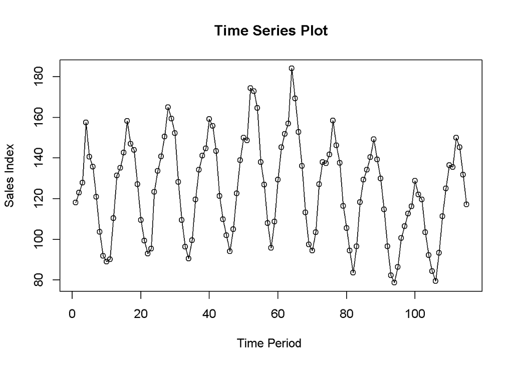

```r
ts.plot(data_ice.ts, xlab="Time Period ", ylab="Sales Index",
        main = "Time Series Plot")
points(data_ice.ts)
```

## Single Moving Average (SMA) dan Single Exponentional Smoothing (SES)

Selanjutnya akan dilakukan ramalan dan pemulusan dengan metode SMA dan SES karena pola data stasioner atau konstan.

#### Pembagian Data

Pembagian data latih (80%) dan data uji (20%).

```r
training_ma <- data_ice[1:92,]
testing_ma <- data_ice[93:115,]
train_ma.ts <- ts(training_ma$IPN31152N)
test_ma.ts <- ts(testing_ma$IPN31152N)
```

#### Eksplorasi Data

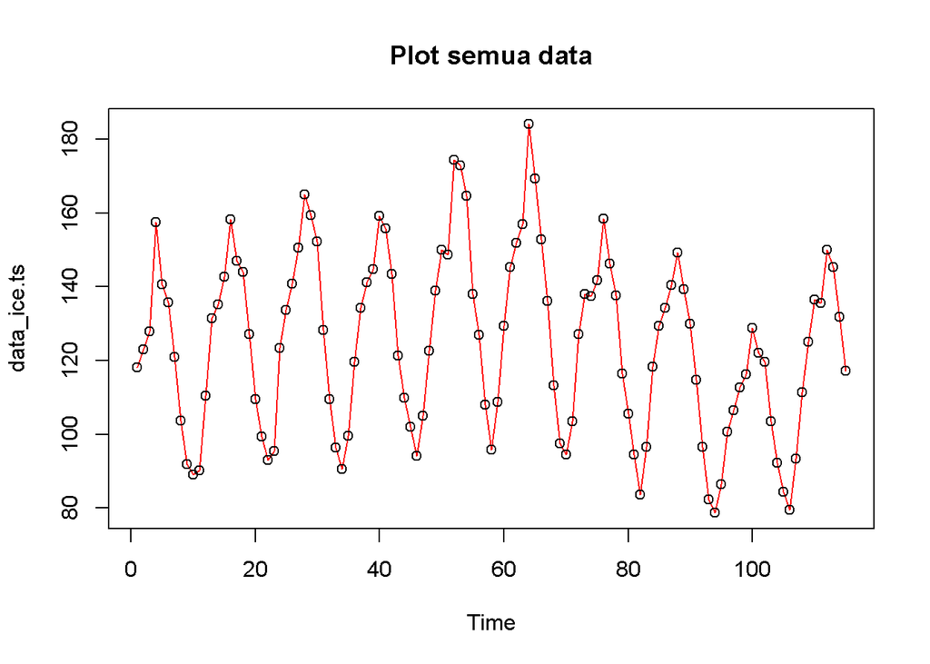

```r
# keseluruhan
plot(data_ice.ts, col="red",main="Plot semua data")
points(data_ice.ts)
```

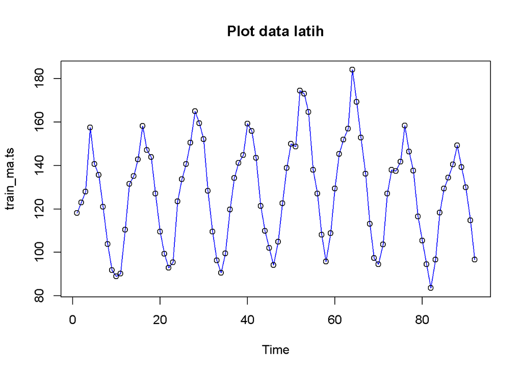

```r
# data latih
plot(train_ma.ts, col="blue",main="Plot data latih")
points(train_ma.ts)
```

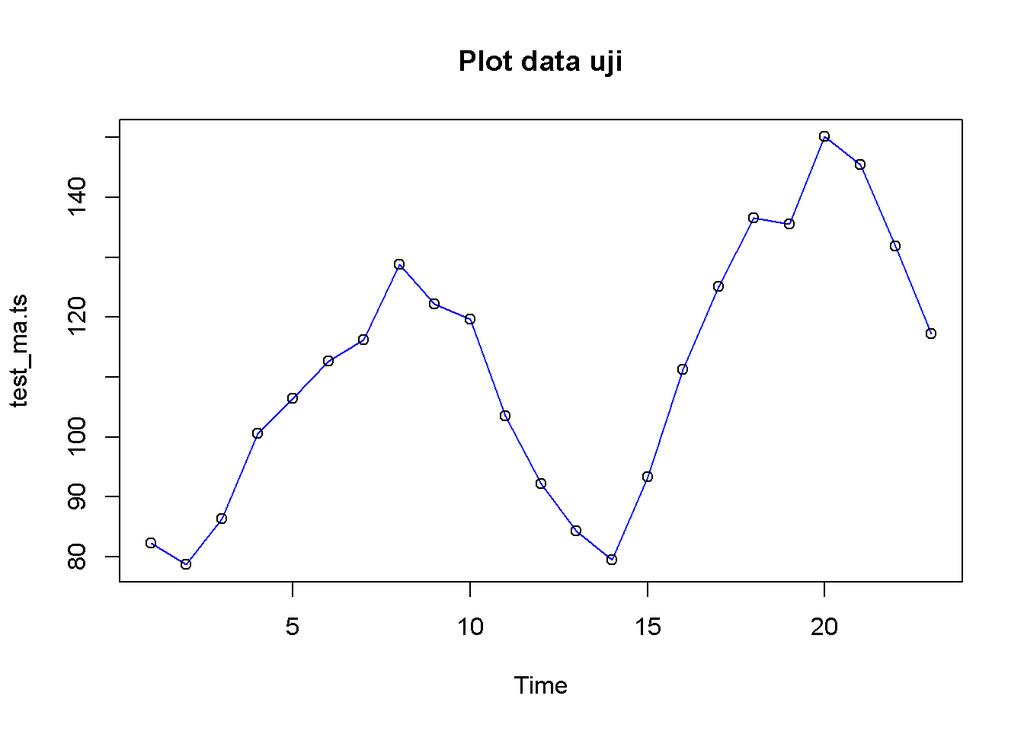

```r
# data uji
plot(test_ma.ts, col="blue",main="Plot data uji")
points(test_ma.ts)
```

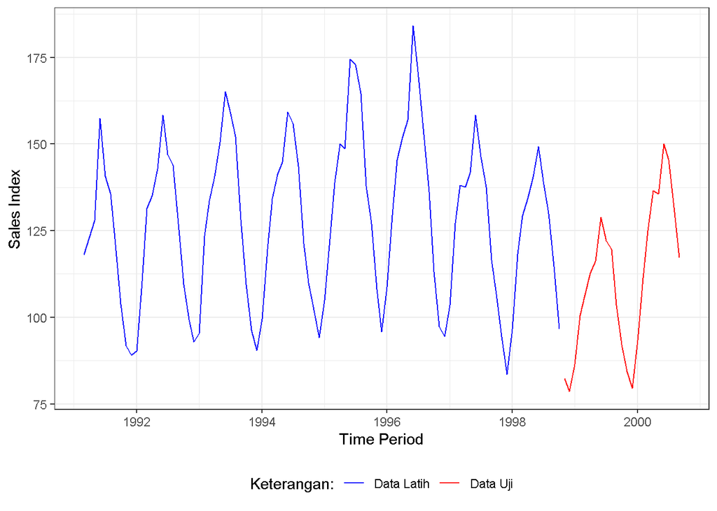

```r
library(ggplot2)
ggplot() +
  # garis untuk data latih
  geom_line(data = training_ma, aes(x = DATE, y = IPN31152N, col = "Data Latih")) +
  # garis untuk data uji
  geom_line(data = testing_ma, aes(x = DATE, y = IPN31152N, col = "Data Uji")) +
  # label sumbu dan legenda
  labs(x = "Time Period", y = "Sales Index", color = "Keterangan") +
  # atur warna manual
  scale_colour_manual(
    name = "Keterangan:",
    breaks = c("Data Latih", "Data Uji"),
    values = c("blue", "red")
  ) +
  # tema
  theme_bw() +
  theme(
    legend.position = "bottom",
    plot.caption = element_text(hjust = 0.5, size = 12)
  )
```

#### SMA

Pemulusan menggunakan metode SMA dengan fungsi *SMA()* dan parameter *m=2*

```r
library(TTR)
data.sma <- SMA(train_ma.ts, n=2)
data.sma
```

```
## Time Series:
## Start = 1
## End = 92
## Frequency = 1
##  [1]        NA 120.57390 125.48410 142.71095 149.08515 138.18075 128.33610
##  [8] 112.38000  97.82530  90.44195  89.61315 100.31710 120.93820 133.34070
## [15] 139.00380 150.54075 152.67565 145.49855 135.49565 118.28575 104.42115
## [22]  96.14895  94.16840 109.40210 128.52680 137.18780 145.66060 157.82200
## [29] 162.24080 155.80985 140.25635 118.92835 102.93775  93.40945  94.99305
## [36] 109.59205 126.97820 137.75460 143.02505 152.00965 157.53970 149.69675
## [43] 132.42850 115.62160 106.00090  98.10155  99.53960 113.77050 130.73390
## [50] 144.46440 149.38095 161.58635 173.73955 168.87305 151.33585 132.47520
## [57] 117.54250 101.92270 102.26795 119.09145 137.41450 148.68405 154.46840
## [64] 170.54535 176.74090 161.12585 144.54850 124.70055 105.30115  95.92585
## [71]  99.00575 115.36125 132.61445 137.81535 139.62135 150.05835 152.38620
## [78] 141.95235 127.02600 110.99775 100.00245  89.02775  90.05800 107.39930
## [85] 123.79030 131.84975 137.43695 144.88360 144.24805 134.56740 122.29845
## [92] 105.65075
```

Dilakukan peramalan 1 periode ke depan

```r
data.ramal <- c(NA, data.sma)
data.ramal
```

```
##  [1]        NA        NA 120.57390 125.48410 142.71095 149.08515 138.18075
##  [8] 128.33610 112.38000  97.82530  90.44195  89.61315 100.31710 120.93820
## [15] 133.34070 139.00380 150.54075 152.67565 145.49855 135.49565 118.28575
## [22] 104.42115  96.14895  94.16840 109.40210 128.52680 137.18780 145.66060
## [29] 157.82200 162.24080 155.80985 140.25635 118.92835 102.93775  93.40945
## [36]  94.99305 109.59205 126.97820 137.75460 143.02505 152.00965 157.53970
## [43] 149.69675 132.42850 115.62160 106.00090  98.10155  99.53960 113.77050
## [50] 130.73390 144.46440 149.38095 161.58635 173.73955 168.87305 151.33585
## [57] 132.47520 117.54250 101.92270 102.26795 119.09145 137.41450 148.68405
## [64] 154.46840 170.54535 176.74090 161.12585 144.54850 124.70055 105.30115
## [71]  95.92585  99.00575 115.36125 132.61445 137.81535 139.62135 150.05835
## [78] 152.38620 141.95235 127.02600 110.99775 100.00245  89.02775  90.05800
## [85] 107.39930 123.79030 131.84975 137.43695 144.88360 144.24805 134.56740
## [92] 122.29845 105.65075
```

```r
data.gab<-cbind(aktual=c(train_ma.ts,rep(NA,41)),pemulusan=c(data.sma,rep(NA,41)),ramalan=c(data.ramal,rep(data.ramal[length(data.ramal)],40)))
data.gab
```

```
##          aktual pemulusan   ramalan
##   [1,] 118.1119        NA        NA
##   [2,] 123.0359 120.57390        NA
##   [3,] 127.9323 125.48410 120.57390
##   [4,] 157.4896 142.71095 125.48410
##   [5,] 140.6807 149.08515 142.71095
##   [6,] 135.6808 138.18075 149.08515
##   [7,] 120.9914 128.33610 138.18075
##   [8,] 103.7686 112.38000 128.33610
##   [9,]  91.8820  97.82530 112.38000
##  [10,]  89.0019  90.44195  97.82530
##  [11,]  90.2244  89.61315  90.44195
##  [12,] 110.4098 100.31710  89.61315
##  [13,] 131.4666 120.93820 100.31710
##  [14,] 135.2148 133.34070 120.93820
```

[output cut: 119 more lines]

Plot time series dari hasil peramalan sebagai berikut

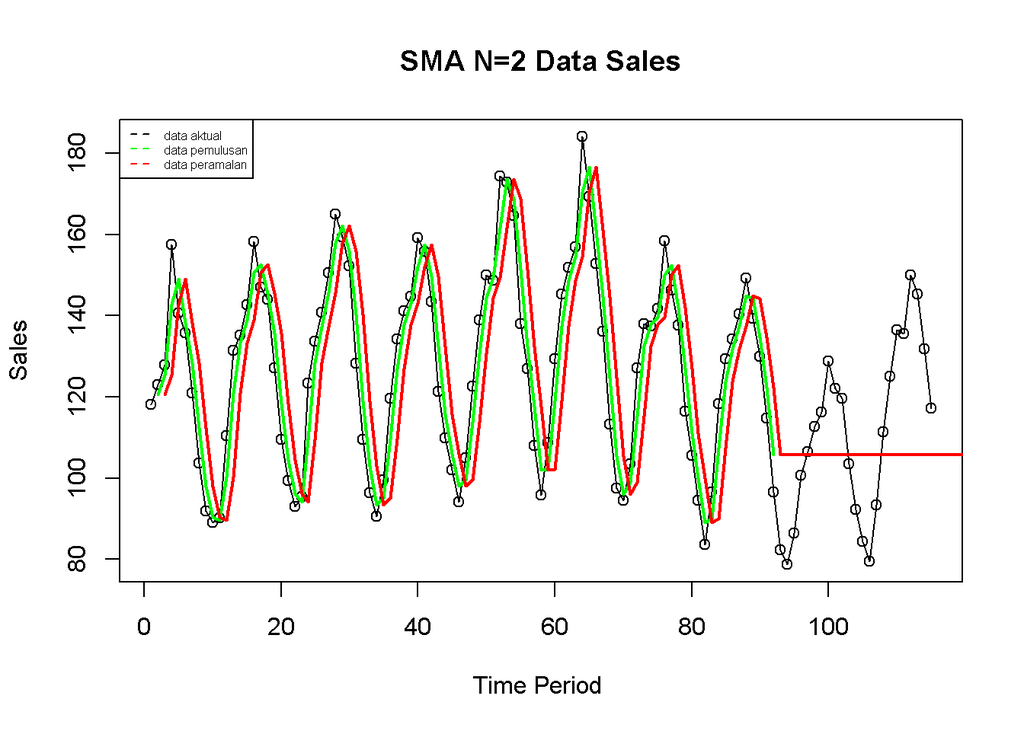

```r
ts.plot(data_ice.ts, xlab="Time Period ", ylab="Sales", main= "SMA N=2 Data Sales")
points(data_ice.ts)
lines(data.gab[,2],col="green",lwd=2)
lines(data.gab[,3],col="red",lwd=2)
legend("topleft",c("data aktual","data pemulusan","data peramalan"), lty=8, col=c("black","green","red"), cex=0.5)
```

Dilakukan perhitungan akurasi pada data latih

```r
error_train.sma = train_ma.ts-data.ramal[1:length(train_ma.ts)]
SSE_train.sma = sum(error_train.sma[5:length(train_ma.ts)]^2)
MSE_train.sma = mean(error_train.sma[5:length(train_ma.ts)]^2)
MAPE_train.sma = mean(abs((error_train.sma[5:length(train_ma.ts)]/train_ma.ts[5:length(train_ma.ts)])*100))

akurasi_train.sma <- matrix(c(SSE_train.sma, MSE_train.sma, MAPE_train.sma))
row.names(akurasi_train.sma)<- c("SSE", "MSE", "MAPE")
colnames(akurasi_train.sma) <- c("Akurasi m = 2")
akurasi_train.sma
```

```
##      Akurasi m = 2
## SSE    30809.63847
## MSE      350.10953
## MAPE      13.49072
```

Didapatkan nilai MAPE data latih pada metode pemulusan SMA kurang dari 20%, artinya nilai ini cukup baik atau dapat diterima. Dilakukan perhituangan akurasi pada data uji

```r
error_test.sma = test_ma.ts-data.gab[93:115,3]
SSE_test.sma = sum(error_test.sma^2)
MSE_test.sma = mean(error_test.sma^2)
MAPE_test.sma = mean(abs((error_test.sma/test_ma.ts*100)))

akurasi_test.sma <- matrix(c(SSE_test.sma, MSE_test.sma, MAPE_test.sma))
row.names(akurasi_test.sma)<- c("SSE", "MSE", "MAPE")
colnames(akurasi_test.sma) <- c("Akurasi m = 2")
akurasi_test.sma
```

```
##      Akurasi m = 2
## SSE    10953.14714
## MSE      476.22379
## MAPE      16.92508
```

Perhituangan akurasi menggunakan data uji menghasilkan nilai MAPE kurang dari 20%, sehingga nilai akurasi ini dapat dikategorikan cukup baik.

#### Pembagian Data

Pembagian data latih 80% dan data uji 20%

```r
training <- data_ice[1:92,]
testing <- data_ice[93:115,]
train.ts <- ts(training$IPN31152N)
test.ts <- ts(testing$IPN31152N)
```

#### Eksplorasi Data

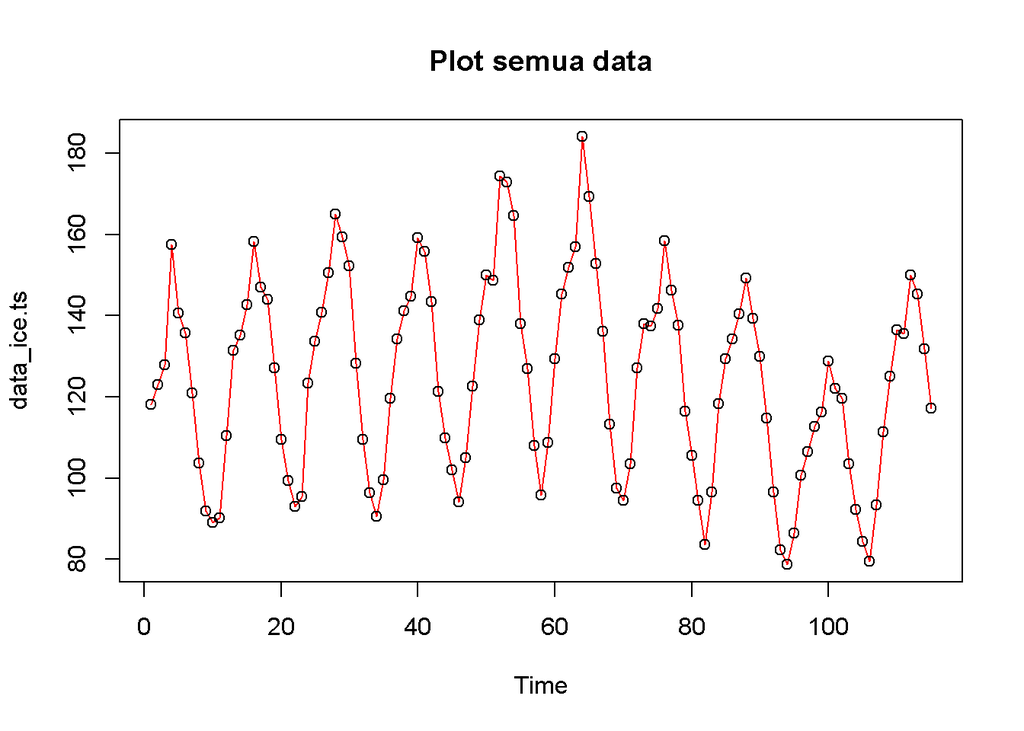

```r
# keseluruhan
plot(data_ice.ts, col="red",main="Plot semua data")
points(data_ice.ts)
```

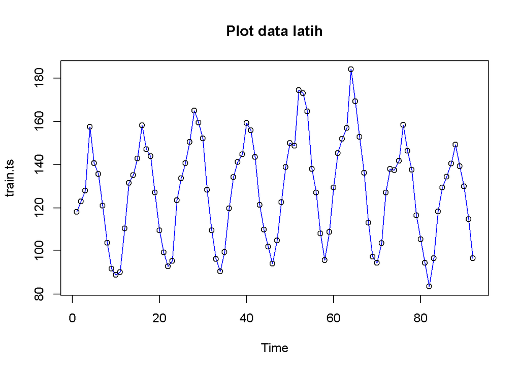

```r
# data latih
plot(train.ts, col="blue",main="Plot data latih")
points(train.ts)
```

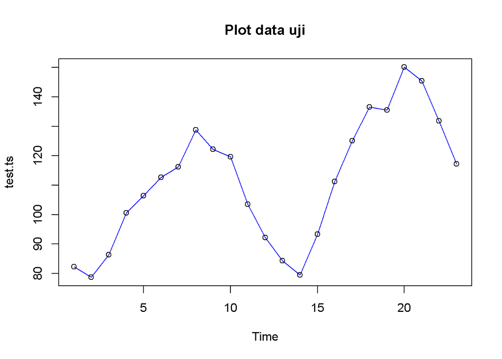

```r
# data uji
plot(test.ts, col="blue",main="Plot data uji")
points(test.ts)
```

Eksplorasi dengan package *ggplot2*

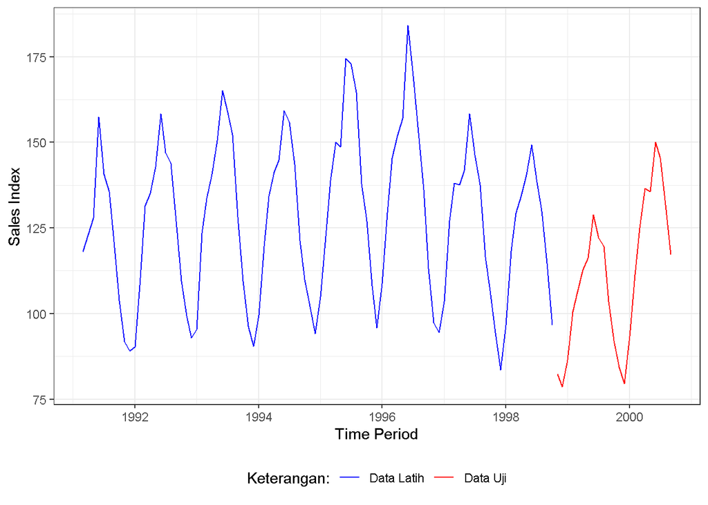

```r
ggplot() +
  # garis untuk data latih
  geom_line(data = training_ma, aes(x = DATE, y = IPN31152N, col = "Data Latih")) +
  # garis untuk data uji
  geom_line(data = testing_ma, aes(x = DATE, y = IPN31152N, col = "Data Uji")) +
  # label sumbu dan legenda
  labs(x = "Time Period", y = "Sales Index", color = "Keterangan") +
  # atur warna manual
  scale_colour_manual(
    name = "Keterangan:",
    breaks = c("Data Latih", "Data Uji"),
    values = c("blue", "red")
  ) +
  # tema
  theme_bw() +
  theme(
    legend.position = "bottom",
    plot.caption = element_text(hjust = 0.5, size = 12)
  )
```

#### SES

Cara pertama adalah menggunakan fungsi *ses()* dari packages *forecast* dengan banyak periode data yang akan diramalkan adalah 23 periode dan nilai *alpha* 0,2 dan 0,7.

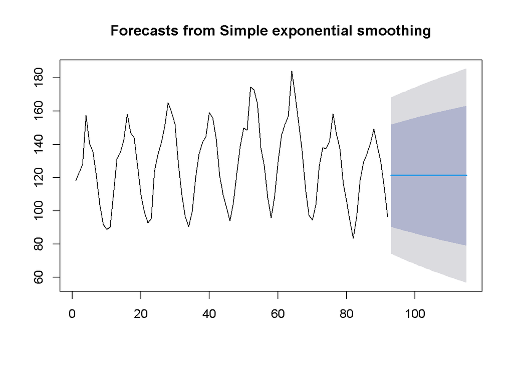

```r
library(forecast)
ses.1 <- ses(train.ts, h = 23, alpha = 0.2)
plot(ses.1)
```

```r
ses.1
```

```
##     Point Forecast    Lo 80    Hi 80    Lo 95    Hi 95
##  93       121.2401 90.51879 151.9614 74.25592 168.2242
##  94       121.2401 89.91039 152.5698 73.32545 169.1547
##  95       121.2401 89.31358 153.1666 72.41271 170.0674
##  96       121.2401 88.72772 153.7524 71.51672 170.9634
##  97       121.2401 88.15224 154.3279 70.63660 171.8436
##  98       121.2401 87.58659 154.8936 69.77152 172.7086
##  99       121.2401 87.03030 155.4499 68.92074 173.5594
## 100       121.2401 86.48291 155.9972 68.08358 174.3966
## 101       121.2401 85.94401 156.5362 67.25940 175.2208
## 102       121.2401 85.41321 157.0669 66.44761 176.0325
## 103       121.2401 84.89016 157.5900 65.64768 176.8325
## 104       121.2401 84.37453 158.1056 64.85909 177.6211
## 105       121.2401 83.86602 158.6141 64.08139 178.3988
## 106       121.2401 83.36433 159.1158 63.31412 179.1660
## 107       121.2401 82.86920 159.6110 62.55689 179.9233
## 108       121.2401 82.38038 160.0998 61.80930 180.6709
## 109       121.2401 81.89764 160.5825 61.07100 181.4092
## 110       121.2401 81.42074 161.0594 60.34165 182.1385
## 111       121.2401 80.94949 161.5307 59.62094 182.8592
## 112       121.2401 80.48369 161.9965 58.90855 183.5716
## 113       121.2401 80.02315 162.4570 58.20422 184.2759
## 114       121.2401 79.56770 162.9125 57.50767 184.9725
## 115       121.2401 79.11717 163.3630 56.81865 185.6615
```

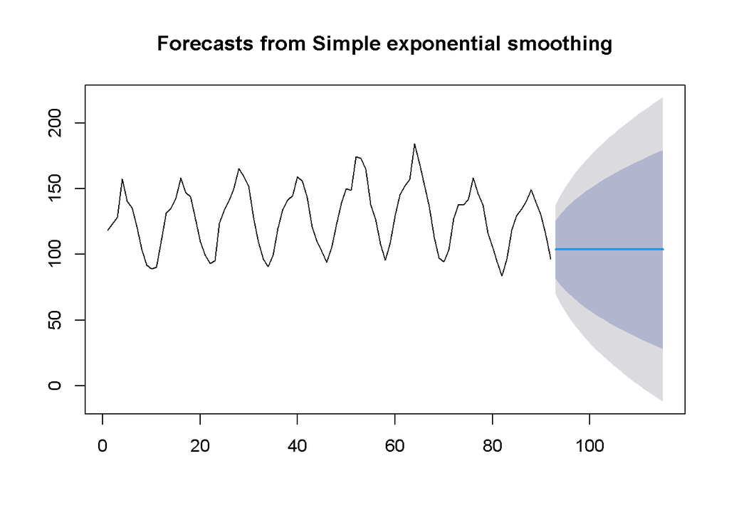

```r
ses.2<- ses(train.ts, h = 23, alpha = 0.7)
plot(ses.2)
```

```r
ses.2
```

```
##     Point Forecast    Lo 80    Hi 80       Lo 95    Hi 95
##  93       103.6947 81.64093 125.7484  69.9663763 137.4230
##  94       103.6947 76.77464 130.6147  62.5240393 144.8653
##  95       103.6947 72.66230 134.7271  56.2347512 151.1546
##  96       103.6947 69.03449 138.3549  50.6864918 156.7029
##  97       103.6947 65.75197 141.6374  45.6663147 161.7230
##  98       103.6947 62.73165 144.6577  41.0471393 166.3422
##  99       103.6947 59.91923 147.4701  36.7459121 170.6434
## 100       103.6947 57.27690 150.1125  32.7048168 174.6845
## 101       103.6947 54.77709 152.6123  28.8816875 178.5077
## 102       103.6947 52.39896 154.9904  25.2446513 182.1447
## 103       103.6947 50.12630 157.2630  21.7689199 185.6204
## 104       103.6947 47.94622 159.4431  18.4347637 188.9546
## 105       103.6947 45.84823 161.5411  15.2261744 192.1632
## 106       103.6947 43.82372 163.5656  12.1299508 195.2594
## 107       103.6947 41.86546 165.5239   9.1350544 198.2543
## 108       103.6947 39.96735 167.4220   6.2321439 201.1572
## 109       103.6947 38.12416 169.2652   3.4132305 203.9761
## 110       103.6947 36.33139 171.0580   0.6714192 206.7179
## 111       103.6947 34.58511 172.8042  -1.9992906 209.3886
## 112       103.6947 32.88187 174.5075  -4.6041592 211.9935
## 113       103.6947 31.21866 176.1707  -7.1478287 214.5372
## 114       103.6947 29.59276 177.7966  -9.6344199 217.0238
## 115       103.6947 28.00179 179.3876 -12.0676111 219.4570
```

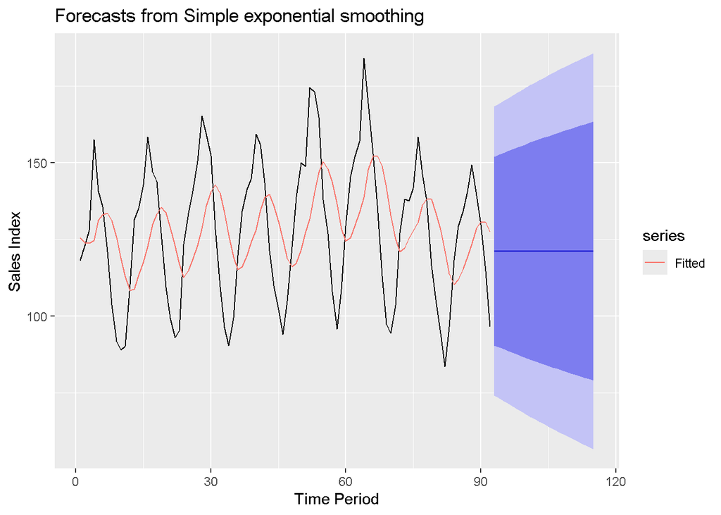

```r
autoplot(ses.1) +
  autolayer(fitted(ses.1), series="Fitted") +
  ylab("Sales Index") + xlab("Time Period")
```

Cara kedua adalah menggunakan fungsi *HoltWinters()* dengan inisialisasi parameter dan panjang periode peramalan yang sama dengan fungsi ses()

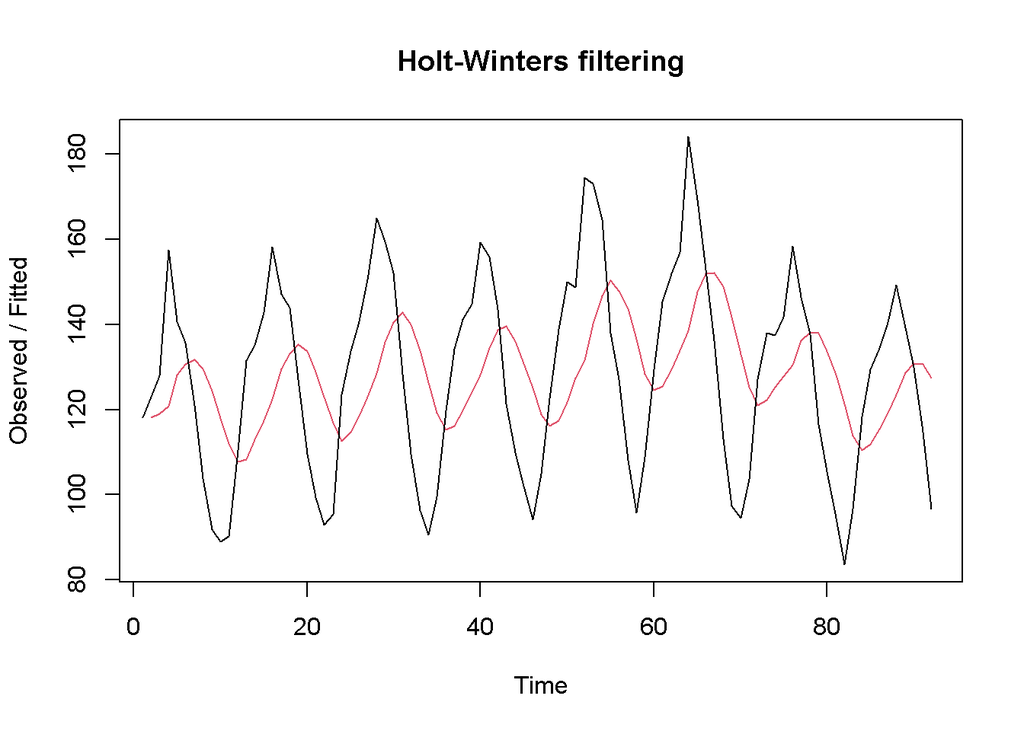

```r
ses1<- HoltWinters(train.ts, gamma = FALSE, beta = FALSE, alpha = 0.2)
plot(ses1)
```

```r
# ramalan
ramalan1 <- forecast(ses1, h=23)
ramalan1
```

```
##     Point Forecast    Lo 80    Hi 80    Lo 95    Hi 95
##  93       121.2401 90.47476 152.0054 74.18858 168.2916
##  94       121.2401 89.86548 152.6147 73.25678 169.2234
##  95       121.2401 89.26782 153.2123 72.34273 170.1374
##  96       121.2401 88.68112 153.7990 71.44545 171.0347
##  97       121.2401 88.10481 154.3753 70.56406 171.9161
##  98       121.2401 87.53836 154.9418 69.69775 172.7824
##  99       121.2401 86.98127 155.4989 68.84575 173.6344
## 100       121.2401 86.43309 156.0471 68.00739 174.4728
## 101       121.2401 85.89342 156.5867 67.18202 175.2981
## 102       121.2401 85.36186 157.1183 66.36907 176.1111
## 103       121.2401 84.83806 157.6421 65.56800 176.9122
## 104       121.2401 84.32169 158.1585 64.77828 177.7019
## 105       121.2401 83.81245 158.6677 63.99946 178.4807
## 106       121.2401 83.31004 159.1701 63.23110 179.2491
## 107       121.2401 82.81421 159.6660 62.47278 180.0074
## 108       121.2401 82.32468 160.1555 61.72412 180.7560
## 109       121.2401 81.84124 160.6389 60.98476 181.4954
## 110       121.2401 81.36367 161.1165 60.25437 182.2258
## 111       121.2401 80.89174 161.5884 59.53262 182.9475
## 112       121.2401 80.42527 162.0549 58.81921 183.6609
## 113       121.2401 79.96407 162.5161 58.11387 184.3663
## 114       121.2401 79.50797 162.9722 57.41632 185.0638
## 115       121.2401 79.05680 163.4234 56.72631 185.7538
```

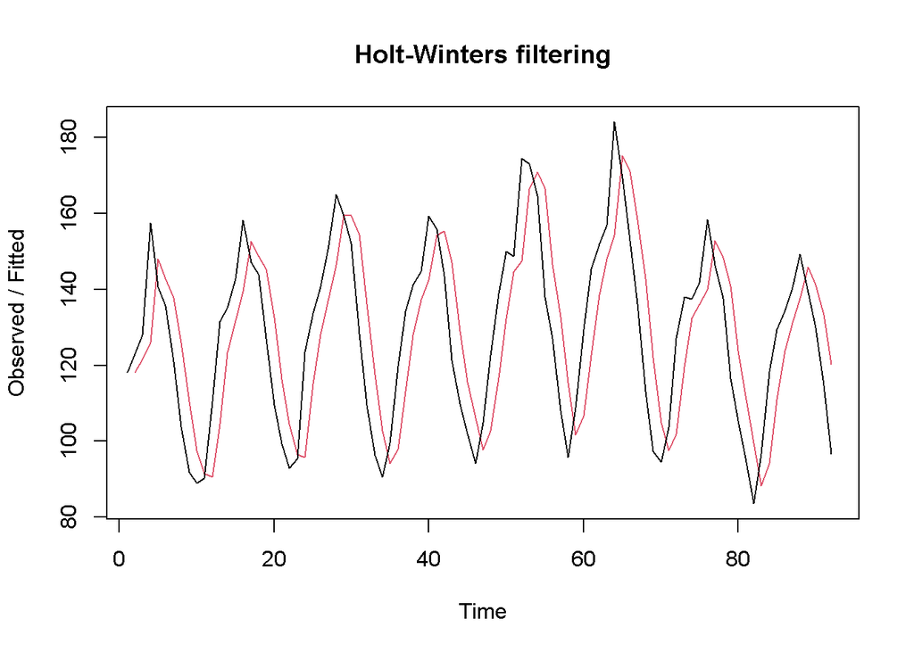

```r
ses2<- HoltWinters(train.ts, gamma = FALSE, beta = FALSE, alpha = 0.7)
plot(ses2)
```

```r
# ramalan
ramalan2<- forecast(ses2, h=23)
ramalan2
```

```
##     Point Forecast    Lo 80    Hi 80       Lo 95    Hi 95
##  93       103.6947 81.63989 125.7495  69.9647962 137.4246
##  94       103.6947 76.77338 130.6160  62.5221105 144.8672
##  95       103.6947 72.66085 134.7285  56.2325278 151.1568
##  96       103.6947 69.03286 138.3565  50.6840084 156.7053
##  97       103.6947 65.75019 141.6392  45.6635961 161.7258
##  98       103.6947 62.72973 144.6596  41.0442043 166.3451
##  99       103.6947 59.91718 147.4722  36.7427756 170.6466
## 100       103.6947 57.27473 150.1146  32.7014910 174.6879
## 101       103.6947 54.77480 152.6146  28.8781826 178.5112
## 102       103.6947 52.39656 154.9928  25.2409760 182.1484
## 103       103.6947 50.12379 157.2656  21.7650818 185.6243
## 104       103.6947 47.94360 159.4457  18.4307694 188.9586
## 105       103.6947 45.84552 161.5438  15.2220297 192.1673
## 106       103.6947 43.82092 163.5684  12.1256610 195.2637
## 107       103.6947 41.86257 165.5268   9.1306243 198.2587
## 108       103.6947 39.96437 167.4250   6.2275778 201.1618
## 109       103.6947 38.12109 169.2683   3.4085324 203.9808
## 110       103.6947 36.32823 171.0611   0.6665927 206.7228
## 111       103.6947 34.58187 172.8075  -2.0042423 209.3936
## 112       103.6947 32.87856 174.5108  -4.6092329 211.9986
## 113       103.6947 31.21526 176.1741  -7.1530215 214.5424
## 114       103.6947 29.58929 177.8001  -9.6397293 217.0291
## 115       103.6947 27.99824 179.3911 -12.0730344 219.4624
```

Mengoptimalkan nilai parameter alpha dari kedua fungsi dengan menyesuaikan dari error-nya paling minimum (*alpha = NULL*)

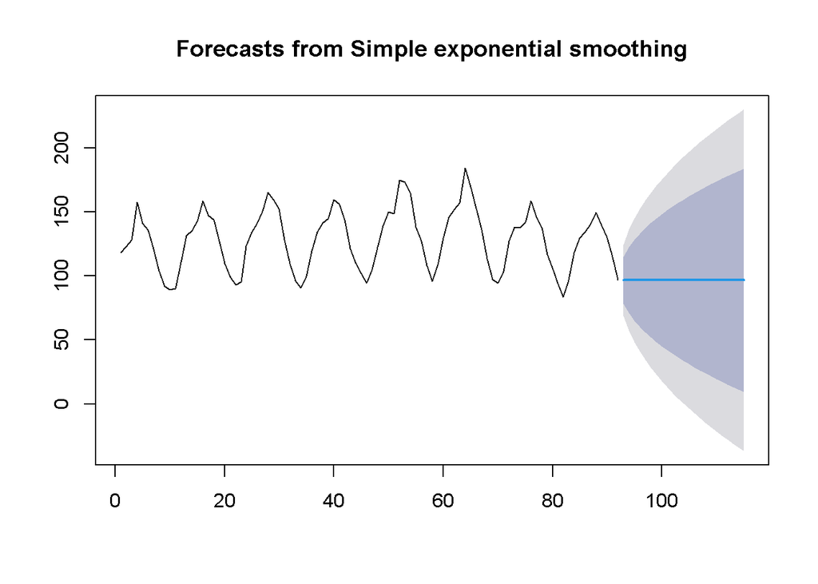

```r
ses.opt <- ses(train.ts, h = 23, alpha = NULL)
plot(ses.opt)
```

```r
ses.opt
```

```
##     Point Forecast     Lo 80    Hi 80       Lo 95    Hi 95
##  93       96.58581 78.397932 114.7737  68.7698494 124.4018
##  94       96.58581 70.865551 122.3061  57.2500669 135.9216
##  95       96.58581 65.085579 128.0860  48.4103626 144.7613
##  96       96.58581 60.212779 132.9588  40.9580581 152.2136
##  97       96.58581 55.919728 137.2519  34.3924033 158.7792
##  98       96.58581 52.038498 141.1331  28.4565732 164.7151
##  99       96.58581 48.469328 144.7023  22.9979987 170.1736
## 100       96.58581 45.147218 148.0244  17.9172709 175.2544
## 101       96.58581 42.027020 151.1446  13.1453395 180.0263
## 102       96.58581 39.075860 154.0958   8.6319289 184.5397
## 103       96.58581 36.268920 156.9027   4.3390850 188.8325
## 104       96.58581 33.586921 159.5847   0.2373209 192.9343
## 105       96.58581 31.014529 162.1571  -3.6968128 196.8684
## 106       96.58581 28.539313 164.6323  -7.4823288 200.6540
## 107       96.58581 26.151027 167.0206 -11.1348965 204.3065
## 108       96.58581 23.841109 169.3305 -14.6676110 207.8392
## 109       96.58581 21.602316 171.5693 -18.0915494 211.2632
## 110       96.58581 19.428457 173.7432 -21.4161809 214.5878
## 111       96.58581 17.314188 175.8574 -24.6496755 217.8213
## 112       96.58581 15.254863 177.9168 -27.7991410 220.9708
## 113       96.58581 13.246409 179.9252 -30.8708066 224.0424
## 114       96.58581 11.285232 181.8864 -33.8701680 227.0418
## 115       96.58581  9.368143 183.8035 -36.8021028 229.9737
```

```r
#Lamda Optimum Holt Winter
sesopt<- HoltWinters(train.ts, gamma = FALSE, beta = FALSE,alpha = NULL)
sesopt
```

```
## Holt-Winters exponential smoothing without trend and without seasonal component.
##
## Call:
## HoltWinters(x = train.ts, alpha = NULL, beta = FALSE, gamma = FALSE)
##
## Smoothing parameters:
##  alpha: 0.9999339
##  beta : FALSE
##  gamma: FALSE
##
## Coefficients:
##      [,1]
## a 96.5852
```

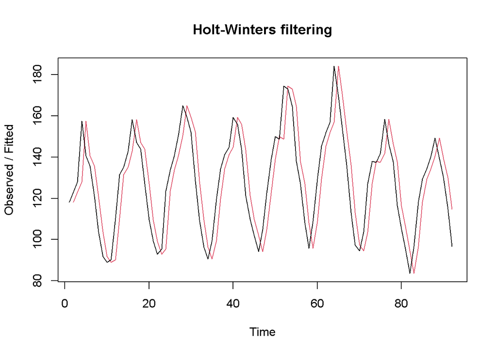

```r
plot(sesopt)
```

```r
# ramalan
ramalanopt <- forecast(sesopt, h=23)
ramalanopt
```

```
##     Point Forecast     Lo 80    Hi 80       Lo 95    Hi 95
##  93        96.5852 78.400190 114.7702  68.7736283 124.3968
##  94        96.5852 70.868563 122.3018  57.2549986 135.9154
##  95        96.5852 65.089228 128.0812  48.4162685 144.7541
##  96        96.5852 60.216985 132.9534  40.9648155 152.2056
##  97        96.5852 55.924434 137.2460  34.3999254 158.7705
##  98        96.5852 52.043661 141.1267  28.4647949 164.7056
##  99        96.5852 48.474915 144.6955  23.0068690 170.1635
## 100        96.5852 45.153203 148.0172  17.9267484 175.2436
## 101        96.5852 42.033379 151.1370  13.1553899 180.0150
## 102        96.5852 39.082574 154.0878   8.6425231 184.5279
## 103        96.5852 36.275973 156.8944   4.3501979 188.8202
## 104        96.5852 33.594299 159.5761   0.2489305 192.9215
## 105        96.5852 31.022219 162.1482  -3.6847258 196.8551
## 106        96.5852 28.547304 164.6231  -7.4697818 200.6402
## 107        96.5852 26.159309 167.0111 -11.1219048 204.2923
## 108        96.5852 23.849673 169.3207 -14.6541889 207.8246
## 109        96.5852 21.611153 171.5592 -18.0777096 211.2481
## 110        96.5852 19.437559 173.7328 -21.4019351 214.5723
## 111        96.5852 17.323549 175.8468 -24.6350344 217.8054
## 112        96.5852 15.264476 177.9059 -27.7841147 220.9545
## 113        96.5852 13.256267 179.9141 -30.8554044 224.0258
## 114        96.5852 11.295331 181.8751 -33.8543985 227.0248
## 115        96.5852  9.378476 183.7919 -36.7859740 229.9564
```

#### Akurasi Data

```r
accuracy(ramalanopt,testing$IPN31152N)
```

```
##                      ME     RMSE      MAE        MPE      MAPE     MASE
## Training set -0.2365728 14.11364 12.31912 -0.8598934  9.860384 1.000038
## Test set     14.7157794 25.70706 21.62134  9.9031862 18.271672 1.755171
##                   ACF1
## Training set 0.5152499
## Test set            NA
```